# Get Started

Book: A PRACTICAL INTRODUCTION, Kieran Healy, Published by Princeton University Press, modified by Lily Popova Zhuhadar

10-August-2020

## Things to know about R

### Everything is an object

```r
c(1, 2, 3, 1, 3, 5, 25)
```

```
## [1]  1  2  3  1  3  5 25
```

```r
my_numbers <- c(1, 2, 3, 1, 3, 5, 25)

your_numbers <- c(5, 31, 71, 1, 3, 21, 6)
```

```r
my_numbers
```

```
## [1]  1  2  3  1  3  5 25
```

### You do things using functions

```r
my_numbers
```

```
## [1]  1  2  3  1  3  5 25
```

```r
mean()
```

```r
mean(x = my_numbers)
```

```
## [1] 5.714286
```

```r
mean(x = your_numbers)
```

```
## [1] 19.71429
```

```r
mean(my_numbers)
```

```
## [1] 5.714286
```

```r
my_summary <- summary(my_numbers)
```

```r
my_summary
```

```
##    Min. 1st Qu.  Median    Mean 3rd Qu.    Max.
##   1.000   1.500   3.000   5.714   4.000  25.000
```

```r
table(my_numbers)
```

```
## my_numbers
##  1  2  3  5 25
##  2  1  2  1  1
```

```r
sd(my_numbers)
```

```
## [1] 8.616153
```

```r
my_numbers * 5
```

```
## [1]   5  10  15   5  15  25 125
```

```r
my_numbers + 1
```

```
## [1]  2  3  4  2  4  6 26
```

```r
my_numbers + my_numbers
```

```
## [1]  2  4  6  2  6 10 50
```

### If you’re not sure what an object is, ask for its class

```r
class(my_numbers)
```

```
## [1] "numeric"
```

```r
class(my_summary)
```

```
## [1] "summaryDefault" "table"
```

```r
class(summary)
```

```
## [1] "function"
```

```r
my_new_vector <- c(my_numbers, "Apple")
my_new_vector
```

```
## [1] "1"     "2"     "3"     "1"     "3"     "5"     "25"    "Apple"
```

```r
class(my_new_vector)
```

```
## [1] "character"
```

```r
titanic
```

```
##       fate    sex    n percent
## 1 perished   male 1364    62.0
## 2 perished female  126     5.7
## 3 survived   male  367    16.7
## 4 survived female  344    15.6
```

```r
class(titanic)
```

```
## [1] "data.frame"
```

```r
temp <- titanic
```

```r
temp$percent
```

```
## [1] 62.0  5.7 16.7 15.6
```

```r
titanic_tb <- as_tibble(titanic)
titanic_tb
```

```
## # A tibble: 4 x 4
##   fate     sex        n percent
##   <fct>    <fct>  <dbl>   <dbl>
## 1 perished male    1364    62
## 2 perished female   126     5.7
## 3 survived male     367    16.7
## 4 survived female   344    15.6
```

### To see inside an object, ask for its structure, or use RStudio’s object inspector

```r
str(my_numbers)
```

```
##  num [1:7] 1 2 3 1 3 5 25
```

```r
str(my_summary)
```

```
##  'summaryDefault' Named num [1:6] 1 1.5 3 5.71 4 ...
##  - attr(*, "names")= chr [1:6] "Min." "1st Qu." "Median" "Mean" ...
```

## Be patient with R, and with yourself

Here are three very specific things to watch out for:

- Make sure parentheses are balanced and that every opening “`(`” has a corresponding closing “`)`”.
- Make sure you complete your expressions. If you think you have completed typing your code, but instead of seeing the `>` command prompt at the console you see the `+` character instead, that may mean R thinks you haven’t written a complete expression yet. You can hit `Esc` or `Ctrl-C` to force your way back to the console and try typing your code again.
- In ggplot specifically, as you will see, we will build up plots a piece at a time by adding expressions to one another. When doing this, make sure your `+` character goes at the end of the line, and not the beginning. That is, write this:

```r
ggplot(data = mpg, aes(x = displ, y = hwy)) + geom_point()
```

and not this:

```r
ggplot(data = mpg, aes(x = displ, y = hwy))
+ geom_point()
```

## Get data into R

Remotely:

```r
url <- "https://cdn.rawgit.com/kjhealy/viz-organdata/master/organdonation.csv"

organs <- read_csv(file = url)
```

Or locally:

```r
organs <- read_csv(file = "data/organdonation.csv")
organs
```

```
## # A tibble: 238 x 21
##    country  year donors   pop pop.dens   gdp gdp.lag health health.lag pubhealth
##    <chr>   <dbl>  <dbl> <dbl>    <dbl> <dbl>   <dbl>  <dbl>      <dbl>     <dbl>
##  1 Austra…    NA  NA    17065    0.220 16774   16591   1300       1224       4.8
##  2 Austra…  1991  12.1  17284    0.223 17171   16774   1379       1300       5.4
##  3 Austra…  1992  12.4  17495    0.226 17914   17171   1455       1379       5.4
##  4 Austra…  1993  12.5  17667    0.228 18883   17914   1540       1455       5.4
##  5 Austra…  1994  10.2  17855    0.231 19849   18883   1626       1540       5.4
##  6 Austra…  1995  10.2  18072    0.233 21079   19849   1737       1626       5.5
##  7 Austra…  1996  10.6  18311    0.237 21923   21079   1846       1737       5.6
##  8 Austra…  1997  10.3  18518    0.239 22961   21923   1948       1846       5.7
##  9 Austra…  1998  10.5  18711    0.242 24148   22961   2077       1948       5.9
## 10 Austra…  1999   8.67 18926    0.244 25445   24148   2231       2077       6.1
## # … with 228 more rows, and 11 more variables: roads <dbl>, cerebvas <dbl>,
## #   assault <dbl>, external <dbl>, txp.pop <dbl>, world <chr>, opt <chr>,
## #   consent.law <chr>, consent.practice <chr>, consistent <chr>, ccode <chr>
```

## Make your first figure

```r
gapminder
```

```
## # A tibble: 1,704 x 6
##    country     continent  year lifeExp      pop gdpPercap
##    <fct>       <fct>     <int>   <dbl>    <int>     <dbl>
##  1 Afghanistan Asia       1952    28.8  8425333      779.
##  2 Afghanistan Asia       1957    30.3  9240934      821.
##  3 Afghanistan Asia       1962    32.0 10267083      853.
##  4 Afghanistan Asia       1967    34.0 11537966      836.
##  5 Afghanistan Asia       1972    36.1 13079460      740.
##  6 Afghanistan Asia       1977    38.4 14880372      786.
##  7 Afghanistan Asia       1982    39.9 12881816      978.
##  8 Afghanistan Asia       1987    40.8 13867957      852.
##  9 Afghanistan Asia       1992    41.7 16317921      649.
## 10 Afghanistan Asia       1997    41.8 22227415      635.
## # … with 1,694 more rows
```

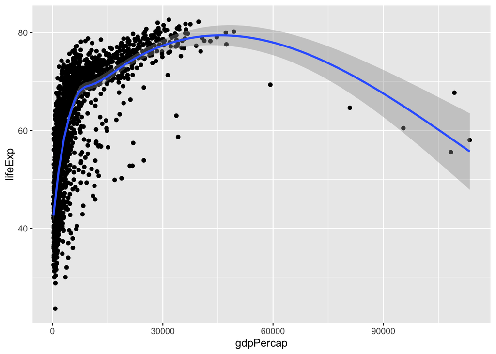

```r
p <- ggplot(data = gapminder,
            mapping = aes(x = gdpPercap, y = lifeExp))
p + geom_point() +
  geom_smooth()
```